# R Notebook for water masses in NES-LTER underway data

Developed by Ayanna Butler as an NES-LTER REU in the Woods Hole PEP, with mentors Stace Beaulieu and Joe Futrelle at WHOI. July 2020

The purpose of this notebook is to identify different water masses using salinity in surface waters of the Northeast U.S. Shelf.

# Import libraries and data

```r
library(tidyverse) # dplyr, ggplot2
```

```r
library(mapdata)
library(oce)
library(metR)
#load data
en644 <- read_csv("https://nes-lter-data.whoi.edu/api/underway/en644.csv")
```

# Create contour plot

This will create contour lines in the background of the plot

```r
t = seq(-2,30,.5)
s = seq(30,37,.05)
tscont <- tibble(temp = rep(t, times = length(s)),
                 sal = rep(s, each = length(t)),
                 rho = oce::swSigma0(sal,temp,0))
```

# Set guess limits for shelf and slope water

This provides boundaries on the plot to delineate shelf, transition, and slope water

```r
wmshelfsalmin = 30
wmshelfmax = 32.25
wmslopemin = 34
wmslopemax = 35.25
```

# Make the temperature and salinity plot

Use the ggplot package to plot salinity vs. temperature and color the plot based on the latitude readings for the data

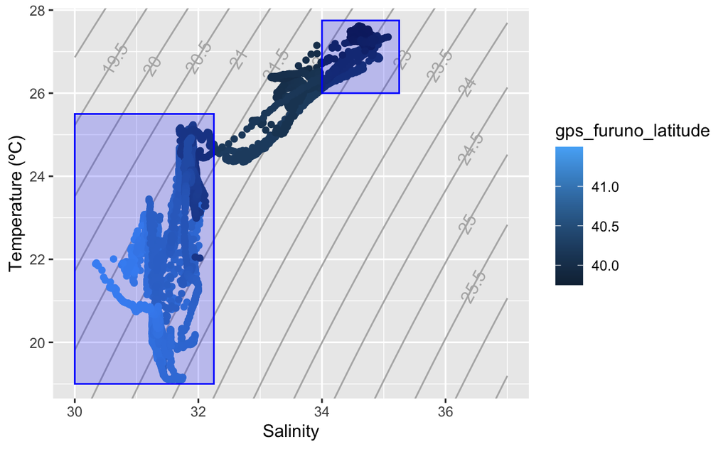

```r
#add the background contours first using the tscont data set
# then add the points from the underway data (can use geom_path also)
# FOR MULTIPLE PROFILES OR UNDERWAY DATA COLOR BY LATITUDE
# COLOR BY DEPTH IF PLOTTING A SINGLE CTD PROFILE
ggplot(en644, aes(tsg2_salinity, tsg1_sst, color = gps_furuno_latitude)) +
  geom_contour(aes(sal, temp, z = rho), data = tscont, breaks = seq(0,100,0.5), color = "grey70") +
  geom_text_contour(aes(sal, temp, z = rho), data = tscont, breaks = seq(0,100,0.5), color = "grey70") +
  geom_point() +
  #coord_cartesian(xlim = range(en644$tsg2_salinity, na.rm = TRUE),
  coord_cartesian(xlim = c(30, 37),
                  ylim = range(en644$tsg1_sst, na.rm = TRUE)) +
annotate("rect", xmin=c(wmshelfsalmin,wmslopemin), xmax=c(wmshelfmax,wmslopemax), ymin=c(19,26) , ymax=c(25.5,27.75), alpha=0.2, color="blue", fill="blue")+
  labs(x = "Salinity", y = "Temperature (ºC)" )
```

# Categorize water masses

This will add a column to the data frame with water mass categories.

```r
# water mass categories:
# not applicable, shelf, transition, slope, gulf stream influenced
# identify salinity column in the data frame and compare the value against the range
# populate a new WaterMass column with the determined category
# creating a new column based on conditional in an existing column
# https://stackoverflow.com/questions/15016723/how-to-add-column-into-a-dataframe-based-on-condition
en644WaterMass<-en644 %>%
  mutate(WaterMass = case_when(tsg2_salinity >= wmslopemax ~ 'Gulf Stream Influenced',
                                tsg2_salinity >= wmslopemin ~ 'Slope Water',
                               tsg2_salinity >=  wmshelfmax ~ ' Transition Water',
                               tsg2_salinity >= wmshelfsalmin ~ 'Shelf Water',
                                  TRUE ~ 'Not Applicable'))
    # mutate(WaterMass = case_when(tsg2_salinity >= 35.5 ~ 'Gulf Stream Influenced',
    #                               tsg2_salinity >= 35 ~ 'Slope Water',
    #                              tsg2_salinity >=  34 ~ ' Transition Water',
    #                              tsg2_salinity >= 30 ~ 'Shelf Water',
    #                               TRUE ~ 'Not Applicable'))

# let's check if we have any rows determined as Gulf Stream Influenced or Slope Water
gsi <- filter(en644WaterMass, WaterMass == 'Gulf Stream Influenced')
nrow(gsi)
```

```
[1] 0
```

```r
slope <- filter(en644WaterMass, WaterMass == 'Slope Water')
nrow(slope)
```

```
[1] 1715
```

# For mapping, set the limits for the longitude and latitude coordinates

We are working in the NW Atlantic/ New England region of the shelf and the specific coordinates to identify that region need to be put in place.

```r
xlims <- c(-72,-69.5)
ylims <- c(39,42.5)
```

# Plot underway data on map

Use the ggplot package to plot the positions colored by water mass.

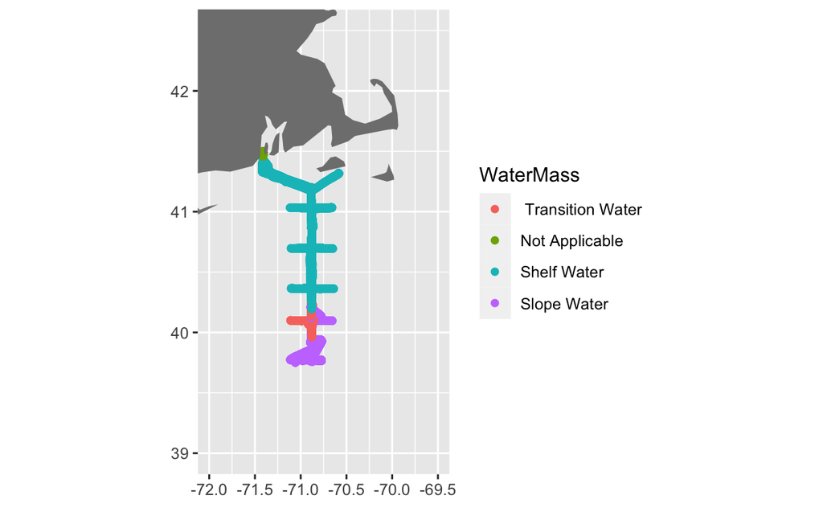

```r
#make map
# ggplot(en644WaterMass, aes(lon,lat)) +
# ggplot allows you to assign aesthetics based on column names
ggplot(en644WaterMass, aes(gps_furuno_longitude,gps_furuno_latitude)) +
  geom_point(aes(color = WaterMass)) +
  geom_polygon(aes(long, lat, group = group), data = map_data("world"), fill = "grey50") +
  coord_quickmap(xlim = xlims, ylim = ylims) +
  labs(x = NULL, y = NULL)
```

# The Next Steps

- Incorporate NEFSC long-term data to be able to understand the range in the temperature-salinity plots.
- Separate this cruise track outbound vs inbound, since points may be taken up to 5 days apart.
- Use higher resolution map data from Ben Harden, or perhaps try R leaflet package with same tileset as IFCB Dashboard.